# Week 5 Demo

```r
library(DALEX)
library(caret)
library(iml)
library(scico)
library(tidyverse)
set.seed(20250227)
theme_set(theme_bw())
```

# Simulate Data

This demo recreates the simulation example from Apley and Zhu (2020). We have two extremely correlated predictors and a noiseless regression $y = x_1 + x_2 ^ 2$.

```r
N <- 1000
df <- data.frame(u = runif(N, 0, 1)) |>
    mutate(
        x1 = u + rnorm(N, 0, 0.05),
        x2 = u + rnorm(N, 0, 0.05),
        y = x1 + x2^2
    )
```

Here are the raw data without any model fitting or explanation. The quadratic effect is extremely subtle, because of the high correlation between features.

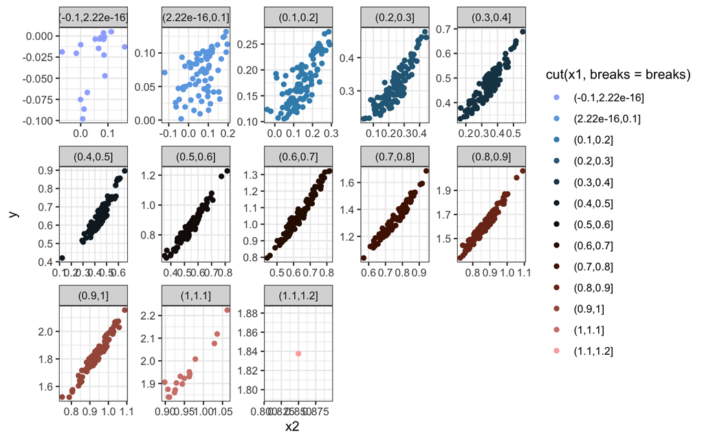

```r
breaks <- seq(-1.2, 1.2, by = 0.1)
ggplot(df, aes(x2, y)) +
    geom_point(aes(col = cut(x1, breaks = breaks))) +
    scale_color_scico_d(palette = "berlin") +
    facet_wrap(~ cut(x1, breaks = breaks), scales = "free", nrow = 3)
```

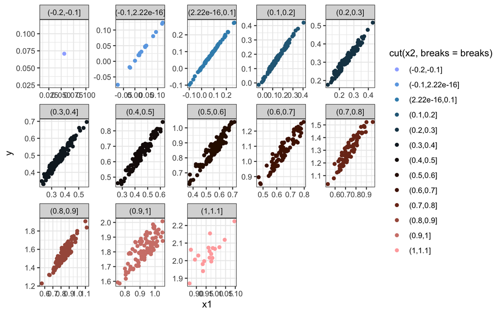

```r
ggplot(df, aes(x1, y)) +
    geom_point(aes(col = cut(x2, breaks = breaks))) +
    scale_color_scico_d(palette = "berlin") +
    facet_wrap(~ cut(x2, breaks = breaks), scales = "free", nrow = 3)
```

# PDP and ALE Profiles

Let’s fit a gradient boosting model to these data.

```r
x <- select(df, starts_with("x"))
fit <- train(x = x, y = df$y, method = "gbm", verbose = FALSE)
```

We’ll use the `iml` package to compute PDP and ALE plots for $x_{2}$. The two approaches actually seem to both recover the quadratic effects reasonably well, though their $y$-axis ranges are not the same (are they being centered somehow?).

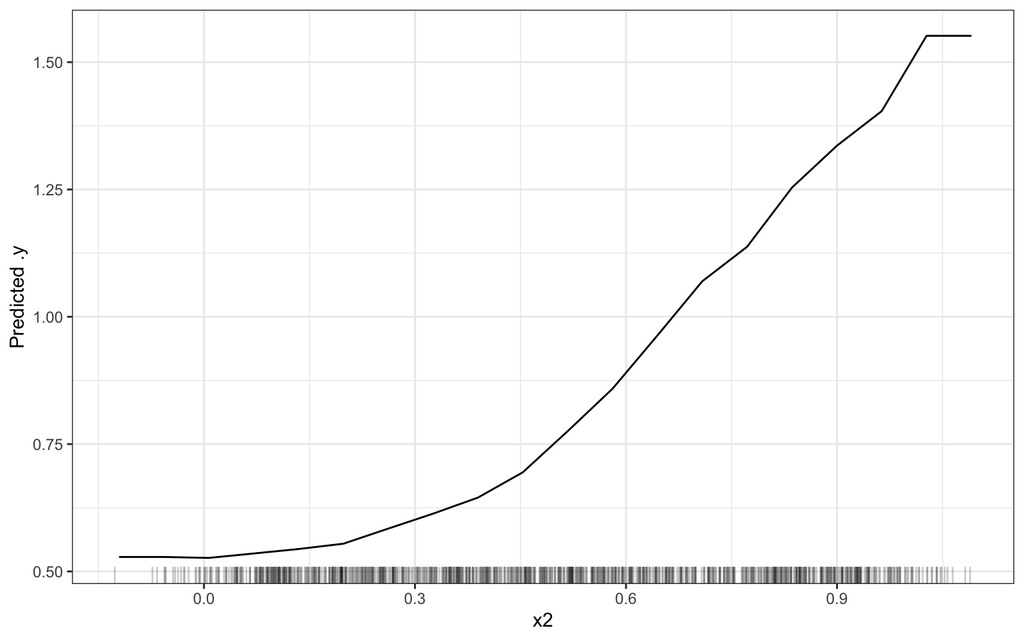

```r
predictor <- Predictor$new(fit, data = x, y = df$y)
pdp <- FeatureEffect$new(predictor, feature = "x2", method = "pdp")
pdp$plot()
```

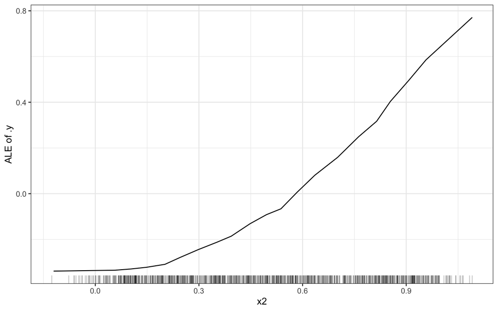

```r
predictor <- Predictor$new(fit, data = x, y = df$y)
ale <- FeatureEffect$new(predictor, feature = "x2", method = "ale")
ale$plot()
```

If someone can give a satisfactory explanation for why these results are different from the paper then they don’t have to do HW2.

# ICE Profiles

It’s also possible to compute the ICE profiles using `iml`, but we want a little more control on the plot, so we’ll extract profiles using the `DALEX` package.

```r
df$y_hat <- predict(fit, x)
explainer <- DALEX::explain(fit, x)
```

[output not shown]

```r
profile <- model_profile(explainer)
profile_df <- as_tibble(profile$cp_profiles)
```

These profiles allow us to see the extrapolation issue. Since the two variables are correlated, we end up averaging curves that are evaluated at $\left(x_{1}, x_{2}\right)$ combinations that we’ve never observed. This attenuates the estimated effects.

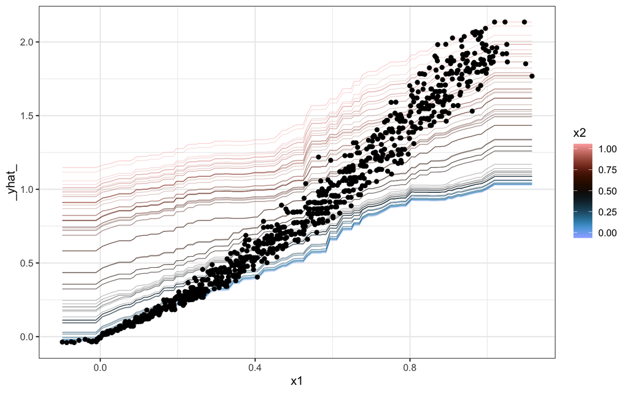

```r
profile_df |>
    filter(`_vname_` == "x1") |>
    ggplot() +
    geom_line(aes(x1, `_yhat_`, group = `_ids_`, col = x2), alpha = 0.4, linewidth = 0.2) +
    scale_color_scico(palette = "berlin") +
    geom_point(data = df, aes(x1, y_hat))
```

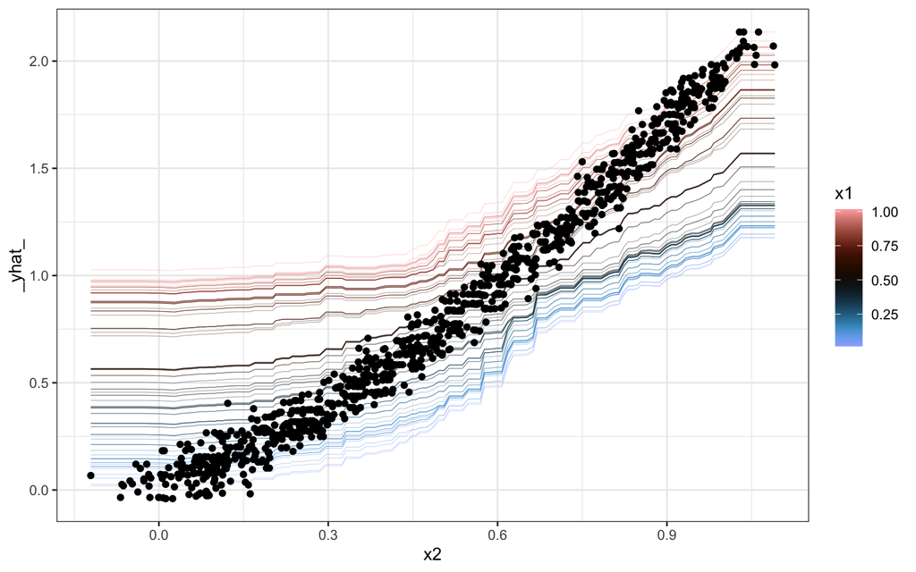

```r
profile_df |>
    filter(`_vname_` == "x2") |>
    ggplot() +
    geom_line(aes(x2, `_yhat_`, group = `_ids_`, col = x1), alpha = 0.4, linewidth = 0.2) +
    scale_color_scico(palette = "berlin") +
    geom_point(data = df, aes(x2, y_hat))
```